# data vis final

In our project, we wanted to see how density and overcrowding in NYC affected covid rates. Below we did a tidycensus API call to collect zip code-level data from the ACS 2015-2019. Then we compared that with covid data from the city, which can be accessed here: https://data.cityofnewyork.us/dataset/DOHMH-COVID-19-Antibody-by-Modified-ZIP-Code-Tabul/6qs8-44ki

```r
library(tidycensus)
library(tidyverse)
library(janitor)
library(ggpubr)
acs_vars <- load_variables(2019, "acs5", cache = TRUE)
```

Even though we only wanted to cover crowding and density, we also wanted to cover our bases and do controls on those variables, so we included a bunch of different variables in the call.

```r
zip_acs_raw <- get_acs(
  geography = "zcta",
  state = "NY",
  variables = c(
    "population" = "B01001_001",
    "white" = "B02001_002",
    "black" = "B02001_003",
    "asian" = "B02001_005",
    "pacific_islander" = "B02001_006",
    "hispanic" = "B03001_003",
    "total_units" = "B25001_001",
    "units_occupied" = "B25002_002",
    "units_vacant" = "B25002_003",
    "owner_occupied" = "B25003_002",
    "renter_occupied" = "B25003_003",
    "crowding_total" = "B25014_001",
    "owner_crowding_total" = "B25014_002",
    "owner_1_1.5_per_room" = "B25014_005",
    "owner_1.5_2_per_room" = "B25014_006",
    "owner_over_2_per_room" = "B25014_007",
    "renter_crowding_total" = "B25014_008",
    "renter_1_1.5_per_room" = "B25014_011",
    "renter_1.5_2_per_room" = "B25014_012",
    "renter_over_2_per_room" = "B25014_013",
    "units_in_structure_total" = "B25024_001",
    "detached" = "B25024_002",
    "attached" = "B25024_003",
    "10_19_unit_structure" = "B25024_007",
    "20_49_unit_structure" = "B25024_008",
    "over_50_unit_structure" = "B25024_009",
    "household_vehicles_total" = "B25044_001",
    "owner_occupied_no_cars" = "B25044_003",
    "renter_occupied_no_cars" = "B25044_010",
    "median_gross_rent" = "B25064_001",
    "rent_percent_hh_income" = "B25071_001",
    "rent_burden_total" = "B25070_001",
    "rent_burden_30_35_percent" = "B25070_007",
    "rent_burden_35_40_percent" = "B25070_008",
    "rent_burden_40_50_percent" = "B25070_009",
    "rent_burden_over_50_percent" = "B25070_010",
    "median_household_income" = "B19013_001",
    "education_total" = "B15003_001",
    "hs_diploma" = "B15003_017",
    "ged" = "B15003_018",
    "college>1" = "B15003_019",
    "college<1_no_degree" = "B15003_020",
    "associates_degree" = "B15003_021",
    "bachelors_degree" = "B15003_022",
    "masters_degree" = "B15003_023",
    "professional_degree" = "B15003_024",
    "doctorate" = "B15003_025",
    "citizenship_total" = "B05001_001",
    "naturalized_citizen" = "B05001_005",
    "non_citizen" = "B05001_006",
    "commute_total" = "B08301_001",
    "commute_by_car" = "B08301_002",
    "commute_by_public_transit" = "B08301_010",
    "commute_by_bus" = "B08301_011",
    "commute_by_subway" = "B08301_012",
    "commute_by_commuter_rail" = "B08301_013",
    "commute_by_other_rail" = "B08301_014",
    "commute_by_walk" = "B08301_019",
    "commute_by_bicycle" = "B08301_018",
    "commute_by_ferry" = "B08301_015",
    "poverty_total" = "C17002_001",
    "poverty_<.5" = "C17002_002",
    "poverty_.5_1.0" = "C17002_003"

  ),
  survey = "acs5",
  year = 2019,
  output = "wide",
  geometry = FALSE
)
write.csv(zip_acs_raw, "zip_acs_raw.csv", row.names = FALSE)
```

I totally forgot to get vacancy data, so I snagged that later.

```r
zip_acs2_raw <- get_acs(
  geography = "zcta",
  state = "NY",
  variables = c(
    "vacancy_total" = "B25004_001",
    "for_rent" = "B25004_002",
    "rented_not_occ" = "B25004_003",
    "for_sale" = "B25004_004",
    "sold_not_occ" = "B25004_005",
    "seasonal_rec_occaisional" = "B25004_006",
    "migrant_worker" = "B25004_007",
    "other_vacant" = "B25004_008"

  ),
  survey = "acs5",
  year = 2019,
  output = "wide",
  geometry = FALSE
)
write.csv(zip_acs2_raw, "zip_acs2_raw.csv", row.names = FALSE)
```

```r
covid_census <- read_csv("combined acs covid zip data - transformations 2.csv",
    col_types = cols(zip = col_character(),
        lat = col_number(), lon = col_number(),
        covid_case_rate = col_number(), population_covid = col_number(),
        covid_death_rate = col_number(),
        covid_positive_percent = col_number(),
        population_acs = col_number(), median_household_income = col_number(),
        median_gross_rent = col_number(),
        white = col_number(), black = col_number(),
        aapi = col_number(), hisp = col_number(),
        nonwhite = col_number(), renter_not_owner = col_number(),
        vacancy_rate_for_rent_or_sale = col_number(),
        crowding = col_number(), severe_crowding = col_number(),
        sfh = col_number(), `10+unit_building` = col_number(),
        `20+unit_building` = col_number(),
        `50+unit_building` = col_number(),
        hhs_no_cars = col_number(), rent_percent_hh_income = col_number(),
        rent_burdened = col_number(), severely_rent_burdened = col_number(),
        `hs_diploma+` = col_number(), `bachelors+` = col_number(),
        foreign_born = col_number(), car_commute = col_number(),
        public_transit = col_number(), `walk+bike` = col_number(),
        poverty = col_number()))
```

We did the join in google sheets, so the full combined data spreadsheet is the one above. Below is a series of correlations and regressions and charts and graphs we made to try to discover the most important variables when it comes to understanding covid spread.

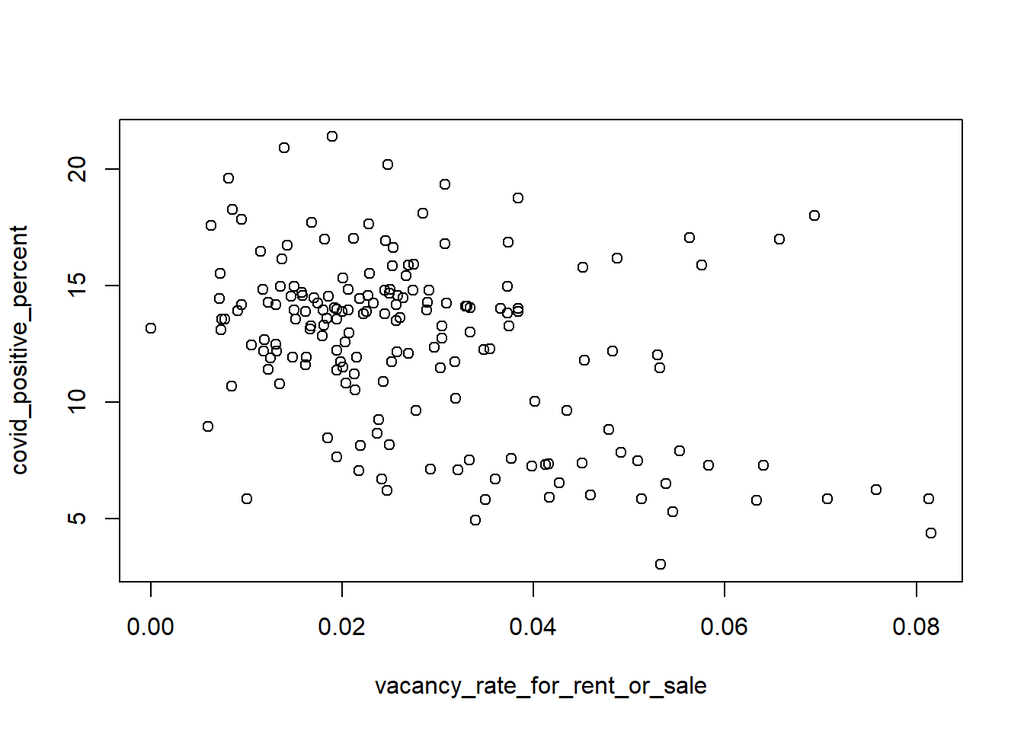

```r
plot(data = covid_census, covid_positive_percent ~ vacancy_rate_for_rent_or_sale)
```

```r
covid_t2 <- read_csv("combined acs covid zip data - t2.csv")
covidt2 <- clean_names(covid_t2)
```

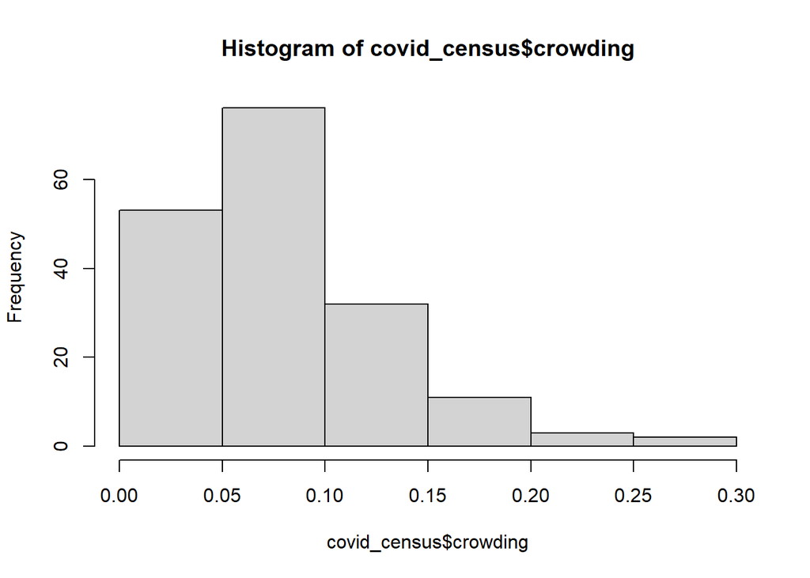

```r
hist(covid_census$crowding)
```

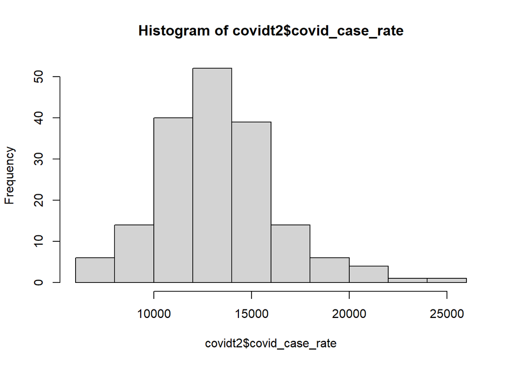

```r
hist(covidt2$covid_case_rate)
```

```r
cor(covid_census$covid_positive_percent, covid_census$aapi)
```

```
## [1] -0.1162561
```

```r
cor(covidt2$covid_case_rate, covidt2$x10_b100)
```

```
## [1] -0.4705827
```

```r
positive.crowding.lm <- lm(data = covid_census, covid_positive_percent ~ crowding)

summary(positive.crowding.lm)
```

```
##
## Call:
## lm(formula = covid_positive_percent ~ crowding, data = covid_census)
##
## Residuals:
##     Min      1Q  Median      3Q     Max
## -9.4854 -1.8979  0.2651  2.0361  9.6368
##
## Coefficients:
##             Estimate Std. Error t value Pr(>|t|)
## (Intercept)  11.3764     0.5328   21.35   <2e-16 ***
## crowding     13.8699     5.5252    2.51    0.013 *
## ---
## Signif. codes:  0 '***' 0.001 '**' 0.01 '*' 0.05 '.' 0.1 ' ' 1
##
## Residual standard error: 3.648 on 175 degrees of freedom
## Multiple R-squared:  0.03476,    Adjusted R-squared:  0.02924
## F-statistic: 6.302 on 1 and 175 DF,  p-value: 0.01297
```

```r
covid.car.rent.lm <- lm(covid_case_rate ~ carcommute100 + median_gross_rent, data = covid_t2)

summary(covid.car.rent.lm)
```

```
##
## Call:
## lm(formula = covid_case_rate ~ carcommute100 + median_gross_rent,
##     data = covid_t2)
##
## Residuals:
##     Min      1Q  Median      3Q     Max
## -5696.1 -1621.1   -48.3  1602.1  7551.7
##
## Coefficients:
##                     Estimate Std. Error t value Pr(>|t|)
## (Intercept)       14618.1035   683.5893  21.384  < 2e-16 ***
## carcommute100        64.0182     8.9479   7.155 2.28e-11 ***
## median_gross_rent    -1.9102     0.3148  -6.068 7.93e-09 ***
## ---
## Signif. codes:  0 '***' 0.001 '**' 0.01 '*' 0.05 '.' 0.1 ' ' 1
##
## Residual standard error: 2302 on 173 degrees of freedom
##   (1 observation deleted due to missingness)
## Multiple R-squared:  0.4379, Adjusted R-squared:  0.4314
## F-statistic: 67.39 on 2 and 173 DF,  p-value: < 2.2e-16
```

```r
covid.density.crowding.lm <- lm(covid_case_rate ~ x10_b100 + crowding100, data = covidt2)

summary(covid.density.crowding.lm)
```

```
##
## Call:
## lm(formula = covid_case_rate ~ x10_b100 + crowding100, data = covidt2)
##
## Residuals:
##     Min      1Q  Median      3Q     Max
## -6485.6 -1734.3  -165.6  1537.2 10941.4
##
## Coefficients:
##              Estimate Std. Error t value Pr(>|t|)
## (Intercept) 14611.580    466.226  31.340  < 2e-16 ***
## x10_b100      -45.352      5.988  -7.574 2.05e-12 ***
## crowding100   127.265     40.208   3.165  0.00183 **
## ---
## Signif. codes:  0 '***' 0.001 '**' 0.01 '*' 0.05 '.' 0.1 ' ' 1
##
## Residual standard error: 2634 on 174 degrees of freedom
## Multiple R-squared:  0.2638, Adjusted R-squared:  0.2554
## F-statistic: 31.18 on 2 and 174 DF,  p-value: 2.672e-12
```

```r
covid.density.lm <- lm(covid_case_rate ~ x10_b100, data = covidt2)

summary(covid.density.lm)
```

```
##
## Call:
## lm(formula = covid_case_rate ~ x10_b100, data = covidt2)
##
## Residuals:
##     Min      1Q  Median      3Q     Max
## -6947.7 -1933.4  -161.3  1595.7 10262.6
##
## Coefficients:
##              Estimate Std. Error t value Pr(>|t|)
## (Intercept) 15543.109    370.797  41.918  < 2e-16 ***
## x10_b100      -42.983      6.092  -7.055 3.86e-11 ***
## ---
## Signif. codes:  0 '***' 0.001 '**' 0.01 '*' 0.05 '.' 0.1 ' ' 1
##
## Residual standard error: 2701 on 175 degrees of freedom
## Multiple R-squared:  0.2214, Adjusted R-squared:  0.217
## F-statistic: 49.78 on 1 and 175 DF,  p-value: 3.86e-11
```

```r
covid.severecrowding.lm <- lm(covid_case_rate ~ severecrowding100, data = covidt2)

summary(covid.severecrowding.lm)
```

```
##
## Call:
## lm(formula = covid_case_rate ~ severecrowding100, data = covidt2)
##
## Residuals:
##     Min      1Q  Median      3Q     Max
## -6431.5 -2063.8  -154.3  1870.0 12349.0
##
## Coefficients:
##                   Estimate Std. Error t value Pr(>|t|)
## (Intercept)       13442.27     401.51  33.479   <2e-16 ***
## severecrowding100   -26.79      99.96  -0.268    0.789
## ---
## Signif. codes:  0 '***' 0.001 '**' 0.01 '*' 0.05 '.' 0.1 ' ' 1
##
## Residual standard error: 3061 on 175 degrees of freedom
## Multiple R-squared:  0.0004103,  Adjusted R-squared:  -0.005302
## F-statistic: 0.07184 on 1 and 175 DF,  p-value: 0.789
```

```r
covid.car.no_car.lm <- lm(covid_case_rate ~ carcommute100 + nocars100, data = covidt2)

summary(covid.car.no_car.lm)
```

```
##
## Call:
## lm(formula = covid_case_rate ~ carcommute100 + nocars100, data = covidt2)
##
## Residuals:
##     Min      1Q  Median      3Q     Max
## -6531.3 -1524.2   -53.5  1605.8  6955.8
##
## Coefficients:
##               Estimate Std. Error t value Pr(>|t|)
## (Intercept)    2275.19    2127.56   1.069    0.286
## carcommute100   197.74      29.30   6.749 2.13e-10 ***
## nocars100       103.43      25.27   4.094 6.49e-05 ***
## ---
## Signif. codes:  0 '***' 0.001 '**' 0.01 '*' 0.05 '.' 0.1 ' ' 1
##
## Residual standard error: 2416 on 174 degrees of freedom
## Multiple R-squared:  0.3809, Adjusted R-squared:  0.3738
## F-statistic: 53.52 on 2 and 174 DF,  p-value: < 2.2e-16
```

```r
covid.foreignborn.lm <- lm(covid_case_rate ~ foreign100, data = covidt2)

summary(covid.foreignborn.lm)
```

```
##
## Call:
## lm(formula = covid_case_rate ~ foreign100, data = covidt2)
##
## Residuals:
##     Min      1Q  Median      3Q     Max
## -6355.2 -2030.3  -197.6  1538.7 13248.6
##
## Coefficients:
##             Estimate Std. Error t value Pr(>|t|)
## (Intercept) 12453.52     686.81  18.132   <2e-16 ***
## foreign100     25.60      18.41   1.391    0.166
## ---
## Signif. codes:  0 '***' 0.001 '**' 0.01 '*' 0.05 '.' 0.1 ' ' 1
##
## Residual standard error: 3045 on 175 degrees of freedom
## Multiple R-squared:  0.01093,    Adjusted R-squared:  0.005278
## F-statistic: 1.934 on 1 and 175 DF,  p-value: 0.1661
```

```r
covid.aapi.lm <- lm(covid_case_rate ~ aapi100, data = covidt2)

summary(covid.aapi.lm)
```

```
##
## Call:
## lm(formula = covid_case_rate ~ aapi100, data = covidt2)
##
## Residuals:
##     Min      1Q  Median      3Q     Max
## -6396.0 -1958.0  -217.1  1658.9 12089.4
##
## Coefficients:
##             Estimate Std. Error t value Pr(>|t|)
## (Intercept) 13717.72     335.43  40.896   <2e-16 ***
## aapi100       -24.14      16.29  -1.482     0.14
## ---
## Signif. codes:  0 '***' 0.001 '**' 0.01 '*' 0.05 '.' 0.1 ' ' 1
##
## Residual standard error: 3042 on 175 degrees of freedom
## Multiple R-squared:  0.01239,    Adjusted R-squared:  0.006749
## F-statistic: 2.196 on 1 and 175 DF,  p-value: 0.1402
```

```r
covid.crowding.lm <- lm(covid_case_rate ~ crowding100, data = covidt2)

summary(covid.crowding.lm)
```

```
##
## Call:
## lm(formula = covid_case_rate ~ crowding100, data = covidt2)
##
## Residuals:
##     Min      1Q  Median      3Q     Max
## -6445.5 -1761.3  -297.9  1499.4 12997.0
##
## Coefficients:
##             Estimate Std. Error t value Pr(>|t|)
## (Intercept) 12616.59     442.31  28.524   <2e-16 ***
## crowding100    89.20      45.87   1.945   0.0534 .
## ---
## Signif. codes:  0 '***' 0.001 '**' 0.01 '*' 0.05 '.' 0.1 ' ' 1
##
## Residual standard error: 3029 on 175 degrees of freedom
## Multiple R-squared:  0.02115,    Adjusted R-squared:  0.01556
## F-statistic: 3.782 on 1 and 175 DF,  p-value: 0.05342
```

```r
covid.poverty.lm <- lm(covid_case_rate ~ poverty100, data = covidt2)

summary(covid.poverty.lm)
```

```
##
## Call:
## lm(formula = covid_case_rate ~ poverty100, data = covidt2)
##
## Residuals:
##     Min      1Q  Median      3Q     Max
## -5847.7 -1878.5  -173.3  1574.8 13138.5
##
## Coefficients:
##             Estimate Std. Error t value Pr(>|t|)
## (Intercept) 12510.15     441.02  28.366   <2e-16 ***
## poverty100     53.48      23.96   2.232   0.0269 *
## ---
## Signif. codes:  0 '***' 0.001 '**' 0.01 '*' 0.05 '.' 0.1 ' ' 1
##
## Residual standard error: 3019 on 175 degrees of freedom
## Multiple R-squared:  0.02767,    Adjusted R-squared:  0.02211
## F-statistic:  4.98 on 1 and 175 DF,  p-value: 0.02692
```

```r
covid.vacancy.lm <- lm(covid_case_rate ~ vacancy100, data = covidt2)

summary(covid.vacancy.lm)
```

```
##
## Call:
## lm(formula = covid_case_rate ~ vacancy100, data = covidt2)
##
## Residuals:
##     Min      1Q  Median      3Q     Max
## -7018.0 -2072.2  -278.7  1582.6 11728.9
##
## Coefficients:
##             Estimate Std. Error t value Pr(>|t|)
## (Intercept)  14269.9      463.7  30.771   <2e-16 ***
## vacancy100    -328.0      144.8  -2.264   0.0248 *
## ---
## Signif. codes:  0 '***' 0.001 '**' 0.01 '*' 0.05 '.' 0.1 ' ' 1
##
## Residual standard error: 3017 on 175 degrees of freedom
## Multiple R-squared:  0.02846,    Adjusted R-squared:  0.02291
## F-statistic: 5.126 on 1 and 175 DF,  p-value: 0.02479
```

```r
covid.hisp.lm <- lm(covid_case_rate ~ hisp100, data = covidt2)

summary(covid.hisp.lm)
```

```
##
## Call:
## lm(formula = covid_case_rate ~ hisp100, data = covidt2)
##
## Residuals:
##     Min      1Q  Median      3Q     Max
## -5798.6 -1974.3  -194.3  1366.3 13266.5
##
## Coefficients:
##             Estimate Std. Error t value Pr(>|t|)
## (Intercept) 12234.66     372.64  32.832  < 2e-16 ***
## hisp100        42.81      11.46   3.735 0.000254 ***
## ---
## Signif. codes:  0 '***' 0.001 '**' 0.01 '*' 0.05 '.' 0.1 ' ' 1
##
## Residual standard error: 2946 on 175 degrees of freedom
## Multiple R-squared:  0.07383,    Adjusted R-squared:  0.06854
## F-statistic: 13.95 on 1 and 175 DF,  p-value: 0.0002538
```

```r
covid.ba.income.lm <- lm(covid_case_rate ~ ba_100 + median_household_income, data = covidt2)

summary(covid.ba.income.lm)
```

```
##
## Call:
## lm(formula = covid_case_rate ~ ba_100 + median_household_income,
##     data = covidt2)
##
## Residuals:
##     Min      1Q  Median      3Q     Max
## -3903.9 -1671.7  -490.5   923.0 13024.0
##
## Coefficients:
##                           Estimate Std. Error t value Pr(>|t|)
## (Intercept)              1.646e+04  4.246e+02  38.767  < 2e-16 ***
## ba_100                  -9.605e+01  1.492e+01  -6.437 1.15e-09 ***
## median_household_income  1.085e-02  7.844e-03   1.383    0.168
## ---
## Signif. codes:  0 '***' 0.001 '**' 0.01 '*' 0.05 '.' 0.1 ' ' 1
##
## Residual standard error: 2520 on 174 degrees of freedom
## Multiple R-squared:  0.3262, Adjusted R-squared:  0.3185
## F-statistic: 42.12 on 2 and 174 DF,  p-value: 1.204e-15
```

```r
covid.ba.lm <- lm(covid_case_rate ~ ba_100, data = covidt2)

summary(covid.ba.lm)
```

```
##
## Call:
## lm(formula = covid_case_rate ~ ba_100, data = covidt2)
##
## Residuals:
##     Min      1Q  Median      3Q     Max
## -3892.0 -1721.2  -417.2   884.3 13162.7
##
## Coefficients:
##              Estimate Std. Error t value Pr(>|t|)
## (Intercept) 16627.477    408.516   40.70  < 2e-16 ***
## ba_100        -79.329      8.765   -9.05 2.71e-16 ***
## ---
## Signif. codes:  0 '***' 0.001 '**' 0.01 '*' 0.05 '.' 0.1 ' ' 1
##
## Residual standard error: 2527 on 175 degrees of freedom
## Multiple R-squared:  0.3188, Adjusted R-squared:  0.3149
## F-statistic: 81.91 on 1 and 175 DF,  p-value: 2.711e-16
```

```r
covid.b10.income.lm <- lm(covid_case_rate ~ x10_b100 + median_household_income, data = covidt2)

summary(covid.b10.income.lm)
```

```
##
## Call:
## lm(formula = covid_case_rate ~ x10_b100 + median_household_income,
##     data = covidt2)
##
## Residuals:
##     Min      1Q  Median      3Q     Max
## -5500.5 -1550.4  -374.7  1301.2 11200.5
##
## Coefficients:
##                           Estimate Std. Error t value Pr(>|t|)
## (Intercept)              1.721e+04  4.674e+02  36.828  < 2e-16 ***
## x10_b100                -3.755e+01  5.762e+00  -6.518 7.44e-10 ***
## median_household_income -2.467e-02  4.659e-03  -5.295 3.55e-07 ***
## ---
## Signif. codes:  0 '***' 0.001 '**' 0.01 '*' 0.05 '.' 0.1 ' ' 1
##
## Residual standard error: 2514 on 174 degrees of freedom
## Multiple R-squared:  0.3295, Adjusted R-squared:  0.3218
## F-statistic: 42.75 on 2 and 174 DF,  p-value: 7.884e-16
```

```r
covid.carcommute.income.lm <- lm(covid_case_rate ~ carcommute100 + median_household_income, data = covidt2)

summary(covid.carcommute.income.lm)
```

```
##
## Call:
## lm(formula = covid_case_rate ~ carcommute100 + median_household_income,
##     data = covidt2)
##
## Residuals:
##     Min      1Q  Median      3Q     Max
## -6268.4 -1634.5  -110.8  1512.3  9363.4
##
## Coefficients:
##                           Estimate Std. Error t value Pr(>|t|)
## (Intercept)              1.302e+04  4.845e+02  26.869  < 2e-16 ***
## carcommute100            7.595e+01  8.534e+00   8.900 7.13e-16 ***
## median_household_income -2.427e-02  4.289e-03  -5.659 6.15e-08 ***
## ---
## Signif. codes:  0 '***' 0.001 '**' 0.01 '*' 0.05 '.' 0.1 ' ' 1
##
## Residual standard error: 2324 on 174 degrees of freedom
## Multiple R-squared:  0.4268, Adjusted R-squared:  0.4202
## F-statistic: 64.77 on 2 and 174 DF,  p-value: < 2.2e-16
```

```r
covid.rent.income.lm <- lm(covid_case_rate ~ median_gross_rent + median_household_income, data = covidt2)

summary(covid.rent.income.lm)
```

```
##
## Call:
## lm(formula = covid_case_rate ~ median_gross_rent + median_household_income,
##     data = covidt2)
##
## Residuals:
##     Min      1Q  Median      3Q     Max
## -5001.3 -1818.7   -77.2  1482.3  7797.0
##
## Coefficients:
##                           Estimate Std. Error t value Pr(>|t|)
## (Intercept)              1.847e+04  6.405e+02  28.837  < 2e-16 ***
## median_gross_rent       -4.317e+00  7.585e-01  -5.691  5.3e-08 ***
## median_household_income  2.574e-02  1.085e-02   2.373   0.0188 *
## ---
## Signif. codes:  0 '***' 0.001 '**' 0.01 '*' 0.05 '.' 0.1 ' ' 1
##
## Residual standard error: 2579 on 173 degrees of freedom
##   (1 observation deleted due to missingness)
## Multiple R-squared:  0.2945, Adjusted R-squared:  0.2864
## F-statistic: 36.11 on 2 and 173 DF,  p-value: 7.819e-14
```

```r
covid.sfh.income.lm <- lm(covid_case_rate ~ sfh100 + median_household_income, data = covidt2)

summary(covid.sfh.income.lm)
```

```
##
## Call:
## lm(formula = covid_case_rate ~ sfh100 + median_household_income,
##     data = covidt2)
##
## Residuals:
##     Min      1Q  Median      3Q     Max
## -6037.7 -1654.1   -98.4  1461.9  8053.5
##
## Coefficients:
##                           Estimate Std. Error t value Pr(>|t|)
## (Intercept)              1.432e+04  4.206e+02  34.050  < 2e-16 ***
## sfh100                   6.619e+01  7.969e+00   8.306 2.69e-14 ***
## median_household_income -2.958e-02  4.327e-03  -6.835 1.33e-10 ***
## ---
## Signif. codes:  0 '***' 0.001 '**' 0.01 '*' 0.05 '.' 0.1 ' ' 1
##
## Residual standard error: 2373 on 174 degrees of freedom
## Multiple R-squared:  0.4027, Adjusted R-squared:  0.3958
## F-statistic: 58.65 on 2 and 174 DF,  p-value: < 2.2e-16
```

```r
covid.carcommute.ba.lm <- lm(covid_case_rate ~ carcommute100 + ba_100, data = covidt2)

summary(covid.carcommute.ba.lm)
```

```
##
## Call:
## lm(formula = covid_case_rate ~ carcommute100 + ba_100, data = covidt2)
##
## Residuals:
##     Min      1Q  Median      3Q     Max
## -5702.1 -1444.8   -13.7  1064.6 10114.0
##
## Coefficients:
##                Estimate Std. Error t value Pr(>|t|)
## (Intercept)   13896.900    578.775  24.011  < 2e-16 ***
## carcommute100    57.493      9.348   6.150 5.15e-09 ***
## ba_100          -54.419      8.937  -6.089 7.07e-09 ***
## ---
## Signif. codes:  0 '***' 0.001 '**' 0.01 '*' 0.05 '.' 0.1 ' ' 1
##
## Residual standard error: 2296 on 174 degrees of freedom
## Multiple R-squared:  0.4405, Adjusted R-squared:  0.434
## F-statistic: 68.49 on 2 and 174 DF,  p-value: < 2.2e-16
```

```r
covid.sfh.rent.lm <- lm(covid_case_rate ~ sfh100 + median_gross_rent, data = covidt2)

summary(covid.sfh.rent.lm)
```

```
##
## Call:
## lm(formula = covid_case_rate ~ sfh100 + median_gross_rent, data = covidt2)
##
## Residuals:
##     Min      1Q  Median      3Q     Max
## -5615.5 -1645.3    55.3  1585.5  6922.8
##
## Coefficients:
##                     Estimate Std. Error t value Pr(>|t|)
## (Intercept)       15945.5235   600.8330  26.539  < 2e-16 ***
## sfh100               52.9085     8.1324   6.506 8.01e-10 ***
## median_gross_rent    -2.2261     0.3095  -7.192 1.85e-11 ***
## ---
## Signif. codes:  0 '***' 0.001 '**' 0.01 '*' 0.05 '.' 0.1 ' ' 1
##
## Residual standard error: 2349 on 173 degrees of freedom
##   (1 observation deleted due to missingness)
## Multiple R-squared:  0.4148, Adjusted R-squared:  0.408
## F-statistic:  61.3 on 2 and 173 DF,  p-value: < 2.2e-16
```

```r
covid.carcommute.rent.lm <- lm(covid_case_rate ~ carcommute100 + median_gross_rent, data = covidt2)

summary(covid.carcommute.rent.lm)
```

```
##
## Call:
## lm(formula = covid_case_rate ~ carcommute100 + median_gross_rent,
##     data = covidt2)
##
## Residuals:
##     Min      1Q  Median      3Q     Max
## -5696.1 -1621.1   -48.3  1602.1  7551.7
##
## Coefficients:
##                     Estimate Std. Error t value Pr(>|t|)
## (Intercept)       14618.1035   683.5893  21.384  < 2e-16 ***
## carcommute100        64.0182     8.9479   7.155 2.28e-11 ***
## median_gross_rent    -1.9102     0.3148  -6.068 7.93e-09 ***
## ---
## Signif. codes:  0 '***' 0.001 '**' 0.01 '*' 0.05 '.' 0.1 ' ' 1
##
## Residual standard error: 2302 on 173 degrees of freedom
##   (1 observation deleted due to missingness)
## Multiple R-squared:  0.4379, Adjusted R-squared:  0.4314
## F-statistic: 67.39 on 2 and 173 DF,  p-value: < 2.2e-16
```

```r
covid.carcommute.ba.rent.sfh.lm <- lm(covid_case_rate ~ carcommute100 + ba_100 + median_gross_rent + sfh100, data = covidt2)

summary(covid.carcommute.ba.rent.sfh.lm)
```

```
##
## Call:
## lm(formula = covid_case_rate ~ carcommute100 + ba_100 + median_gross_rent +
##     sfh100, data = covidt2)
##
## Residuals:
##     Min      1Q  Median      3Q     Max
## -5477.5 -1703.9     7.6  1319.6  8524.5
##
## Coefficients:
##                     Estimate Std. Error t value Pr(>|t|)
## (Intercept)       14890.7171   732.3991  20.331   <2e-16 ***
## carcommute100        44.0320    20.8659   2.110   0.0363 *
## ba_100              -32.3248    14.3864  -2.247   0.0259 *
## median_gross_rent    -1.0829     0.4969  -2.179   0.0307 *
## sfh100               13.5859    18.1717   0.748   0.4557
## ---
## Signif. codes:  0 '***' 0.001 '**' 0.01 '*' 0.05 '.' 0.1 ' ' 1
##
## Residual standard error: 2281 on 171 degrees of freedom
##   (1 observation deleted due to missingness)
## Multiple R-squared:  0.4547, Adjusted R-squared:  0.442
## F-statistic: 35.65 on 4 and 171 DF,  p-value: < 2.2e-16
```

```r
covid.carcommute.sfh.lm <- lm(covid_case_rate ~ carcommute100 + sfh100, data = covidt2)

summary(covid.carcommute.sfh.lm)
```

```
##
## Call:
## lm(formula = covid_case_rate ~ carcommute100 + sfh100, data = covidt2)
##
## Residuals:
##     Min      1Q  Median      3Q     Max
## -6655.0 -1460.9   -31.7  1813.9  8759.7
##
## Coefficients:
##               Estimate Std. Error t value Pr(>|t|)
## (Intercept)   10777.41     368.06  29.282  < 2e-16 ***
## carcommute100    96.36      21.15   4.557 9.75e-06 ***
## sfh100          -13.42      19.57  -0.686    0.494
## ---
## Signif. codes:  0 '***' 0.001 '**' 0.01 '*' 0.05 '.' 0.1 ' ' 1
##
## Residual standard error: 2526 on 174 degrees of freedom
## Multiple R-squared:  0.3231, Adjusted R-squared:  0.3153
## F-statistic: 41.52 on 2 and 174 DF,  p-value: 1.808e-15
```

```r
covid.carcommute.b10.lm <- lm(covid_case_rate ~ carcommute100 + x10_b100, data = covidt2)

summary(covid.carcommute.b10.lm)
```

```
##
## Call:
## lm(formula = covid_case_rate ~ carcommute100 + x10_b100, data = covidt2)
##
## Residuals:
##     Min      1Q  Median      3Q     Max
## -6531.4 -1532.8    28.4  1729.5  8415.2
##
## Coefficients:
##                Estimate Std. Error t value Pr(>|t|)
## (Intercept)   11369.597    889.340  12.784  < 2e-16 ***
## carcommute100    76.364     14.984   5.096 8.96e-07 ***
## x10_b100         -5.441      9.314  -0.584     0.56
## ---
## Signif. codes:  0 '***' 0.001 '**' 0.01 '*' 0.05 '.' 0.1 ' ' 1
##
## Residual standard error: 2527 on 174 degrees of freedom
## Multiple R-squared:  0.3226, Adjusted R-squared:  0.3148
## F-statistic: 41.43 on 2 and 174 DF,  p-value: 1.928e-15
```

```r
covid.carcommute.ba.rent.b10.lm <- lm(covid_case_rate ~ carcommute100 + ba_100 + median_gross_rent + x10_b100, data = covidt2)

summary(covid.carcommute.ba.rent.b10.lm)
```

```
##
## Call:
## lm(formula = covid_case_rate ~ carcommute100 + ba_100 + median_gross_rent +
##     x10_b100, data = covidt2)
##
## Residuals:
##    Min     1Q Median     3Q    Max
##  -5598  -1594    -41   1313   8910
##
## Coefficients:
##                     Estimate Std. Error t value Pr(>|t|)
## (Intercept)       14523.6573   995.6939  14.586  < 2e-16 ***
## carcommute100        60.2334    13.7855   4.369 2.16e-05 ***
## ba_100              -31.7653    14.7155  -2.159   0.0323 *
## median_gross_rent    -1.0540     0.5033  -2.094   0.0377 *
## x10_b100              1.9077     8.6981   0.219   0.8267
## ---
## Signif. codes:  0 '***' 0.001 '**' 0.01 '*' 0.05 '.' 0.1 ' ' 1
##
## Residual standard error: 2284 on 171 degrees of freedom
##   (1 observation deleted due to missingness)
## Multiple R-squared:  0.4531, Adjusted R-squared:  0.4403
## F-statistic: 35.42 on 4 and 171 DF,  p-value: < 2.2e-16
```

```r
covid.crowding.b10.lm <- lm(covid_case_rate ~ crowding100 + x10_b100, data = covidt2)

summary(covid.crowding.b10.lm)
```

```
##
## Call:
## lm(formula = covid_case_rate ~ crowding100 + x10_b100, data = covidt2)
##
## Residuals:
##     Min      1Q  Median      3Q     Max
## -6485.6 -1734.3  -165.6  1537.2 10941.4
##
## Coefficients:
##              Estimate Std. Error t value Pr(>|t|)
## (Intercept) 14611.580    466.226  31.340  < 2e-16 ***
## crowding100   127.265     40.208   3.165  0.00183 **
## x10_b100      -45.352      5.988  -7.574 2.05e-12 ***
## ---
## Signif. codes:  0 '***' 0.001 '**' 0.01 '*' 0.05 '.' 0.1 ' ' 1
##
## Residual standard error: 2634 on 174 degrees of freedom
## Multiple R-squared:  0.2638, Adjusted R-squared:  0.2554
## F-statistic: 31.18 on 2 and 174 DF,  p-value: 2.672e-12
```

```r
covid.carcommute.ba.rent.lm <- lm(covid_case_rate ~ carcommute100 + ba_100 + median_gross_rent, data = covidt2)

summary(covid.carcommute.ba.rent.lm)
```

```
##
## Call:
## lm(formula = covid_case_rate ~ carcommute100 + ba_100 + median_gross_rent,
##     data = covidt2)
##
## Residuals:
##     Min      1Q  Median      3Q     Max
## -5588.0 -1638.7   -57.2  1339.8  8900.7
##
## Coefficients:
##                    Estimate Std. Error t value Pr(>|t|)
## (Intercept)       14683.404    677.009  21.689  < 2e-16 ***
## carcommute100        58.002      9.275   6.253 3.08e-09 ***
## ba_100              -31.003     14.259  -2.174   0.0311 *
## median_gross_rent    -1.071      0.496  -2.159   0.0322 *
## ---
## Signif. codes:  0 '***' 0.001 '**' 0.01 '*' 0.05 '.' 0.1 ' ' 1
##
## Residual standard error: 2278 on 172 degrees of freedom
##   (1 observation deleted due to missingness)
## Multiple R-squared:  0.4529, Adjusted R-squared:  0.4434
## F-statistic: 47.47 on 3 and 172 DF,  p-value: < 2.2e-16
```

```r
covid.ba.sfh.lm <- lm(covid_case_rate ~ ba_100 + sfh100, data = covidt2)

summary(covid.ba.sfh.lm)
```

```
##
## Call:
## lm(formula = covid_case_rate ~ ba_100 + sfh100, data = covidt2)
##
## Residuals:
##    Min     1Q Median     3Q    Max
##  -5512  -1628   -152   1063   9324
##
## Coefficients:
##              Estimate Std. Error t value Pr(>|t|)
## (Intercept) 15009.455    469.761  31.951  < 2e-16 ***
## ba_100        -63.747      8.506  -7.494 3.24e-12 ***
## sfh100         47.239      8.234   5.737 4.18e-08 ***
## ---
## Signif. codes:  0 '***' 0.001 '**' 0.01 '*' 0.05 '.' 0.1 ' ' 1
##
## Residual standard error: 2324 on 174 degrees of freedom
## Multiple R-squared:  0.4272, Adjusted R-squared:  0.4206
## F-statistic: 64.88 on 2 and 174 DF,  p-value: < 2.2e-16
```

```r
covid.crowding.sfh.lm <- lm(covid_case_rate ~ crowding100 + sfh100, data = covidt2)

summary(covid.crowding.sfh.lm)
```

```
##
## Call:
## lm(formula = covid_case_rate ~ crowding100 + sfh100, data = covidt2)
##
## Residuals:
##    Min     1Q Median     3Q    Max
##  -6331  -1550   -258   1580   7326
##
## Coefficients:
##             Estimate Std. Error t value Pr(>|t|)
## (Intercept) 9917.674    463.583  21.394  < 2e-16 ***
## crowding100  210.424     39.744   5.294 3.57e-07 ***
## sfh100        82.197      8.813   9.327  < 2e-16 ***
## ---
## Signif. codes:  0 '***' 0.001 '**' 0.01 '*' 0.05 '.' 0.1 ' ' 1
##
## Residual standard error: 2480 on 174 degrees of freedom
## Multiple R-squared:  0.3474, Adjusted R-squared:  0.3399
## F-statistic: 46.32 on 2 and 174 DF,  p-value: < 2.2e-16
```

```r
covid.crowding.white.lm <- lm(covid_case_rate ~ crowding100 + white100, data = covidt2)

summary(covid.crowding.white.lm)
```

```
##
## Call:
## lm(formula = covid_case_rate ~ crowding100 + white100, data = covidt2)
##
## Residuals:
##     Min      1Q  Median      3Q     Max
## -6594.4 -1793.1  -284.2  1571.1 12814.6
##
## Coefficients:
##              Estimate Std. Error t value Pr(>|t|)
## (Intercept) 12295.835    760.602  16.166   <2e-16 ***
## crowding100    99.656     50.188   1.986   0.0486 *
## white100        5.078      9.785   0.519   0.6045
## ---
## Signif. codes:  0 '***' 0.001 '**' 0.01 '*' 0.05 '.' 0.1 ' ' 1
##
## Residual standard error: 3035 on 174 degrees of freedom
## Multiple R-squared:  0.02267,    Adjusted R-squared:  0.01143
## F-statistic: 2.018 on 2 and 174 DF,  p-value: 0.1361
```

```r
covid.ba.rent.lm <- lm(covid_case_rate ~ ba_100 + median_gross_rent, data = covidt2)

summary(covid.ba.rent.lm)
```

```
##
## Call:
## lm(formula = covid_case_rate ~ ba_100 + median_gross_rent, data = covidt2)
##
## Residuals:
##     Min      1Q  Median      3Q     Max
## -3771.3 -1758.1  -471.3  1051.0 12053.7
##
## Coefficients:
##                     Estimate Std. Error t value Pr(>|t|)
## (Intercept)       17382.4195   576.1676  30.169  < 2e-16 ***
## ba_100              -57.6032    15.0339  -3.832 0.000178 ***
## median_gross_rent    -1.0001     0.5477  -1.826 0.069582 .
## ---
## Signif. codes:  0 '***' 0.001 '**' 0.01 '*' 0.05 '.' 0.1 ' ' 1
##
## Residual standard error: 2516 on 173 degrees of freedom
##   (1 observation deleted due to missingness)
## Multiple R-squared:  0.3286, Adjusted R-squared:  0.3208
## F-statistic: 42.33 on 2 and 173 DF,  p-value: 1.087e-15
```

Here I discovered that the most important variable was one we didn’t have: support for Trump. I tried to do a last-minute proxy for Trump support by just controlling for Staten Island, but that didn’t work all that well, obviously.

```r
covidt23 <- covidt2 %>%
  mutate(staten_island = case_when(
    startsWith(boro, "Staten Island") ~ 1
  ))
```

```r
covidt22 <- covidt2 %>%
  mutate(staten_island = boro == "Staten Island")
```

```r
covid.crowding.staten.lm <- lm(covid_case_rate ~ crowding100 + staten_island, data = covidt22)

summary(covid.crowding.staten.lm)
```

```
##
## Call:
## lm(formula = covid_case_rate ~ crowding100 + staten_island, data = covidt22)
##
## Residuals:
##     Min      1Q  Median      3Q     Max
## -5970.2 -1633.7   -53.2  1368.8 13975.0
##
## Coefficients:
##                   Estimate Std. Error t value Pr(>|t|)
## (Intercept)       11483.05     378.42  30.345  < 2e-16 ***
## crowding100         167.33      38.15   4.386 1.99e-05 ***
## staten_islandTRUE  7191.88     753.16   9.549  < 2e-16 ***
## ---
## Signif. codes:  0 '***' 0.001 '**' 0.01 '*' 0.05 '.' 0.1 ' ' 1
##
## Residual standard error: 2460 on 174 degrees of freedom
## Multiple R-squared:  0.3577, Adjusted R-squared:  0.3503
## F-statistic: 48.46 on 2 and 174 DF,  p-value: < 2.2e-16
```

```r
covid.sfh.staten.lm <- lm(covid_case_rate ~ sfh100 + staten_island, data = covidt22)

summary(covid.sfh.staten.lm)
```

```
##
## Call:
## lm(formula = covid_case_rate ~ sfh100 + staten_island, data = covidt22)
##
## Residuals:
##     Min      1Q  Median      3Q     Max
## -5373.7 -1693.1    -0.4  1513.2  9437.2
##
## Coefficients:
##                    Estimate Std. Error t value Pr(>|t|)
## (Intercept)       12155.820    252.425  48.156  < 2e-16 ***
## sfh100               42.457      9.258   4.586 8.60e-06 ***
## staten_islandTRUE  4747.758    824.255   5.760 3.74e-08 ***
## ---
## Signif. codes:  0 '***' 0.001 '**' 0.01 '*' 0.05 '.' 0.1 ' ' 1
##
## Residual standard error: 2449 on 174 degrees of freedom
## Multiple R-squared:  0.3636, Adjusted R-squared:  0.3563
## F-statistic: 49.71 on 2 and 174 DF,  p-value: < 2.2e-16
```

```r
covid.sfh.staten.income.lm <- lm(covid_case_rate ~ sfh100 + staten_island + median_household_income, data = covidt22)

summary(covid.sfh.staten.income.lm)
```

```
##
## Call:
## lm(formula = covid_case_rate ~ sfh100 + staten_island + median_household_income,
##     data = covidt22)
##
## Residuals:
##    Min     1Q Median     3Q    Max
##  -4636  -1339   -148   1279  10370
##
## Coefficients:
##                           Estimate Std. Error t value Pr(>|t|)
## (Intercept)              1.456e+04  3.755e+02  38.773  < 2e-16 ***
## sfh100                   4.102e+01  7.975e+00   5.144 7.24e-07 ***
## staten_islandTRUE        4.877e+03  7.101e+02   6.869 1.12e-10 ***
## median_household_income -3.019e-02  3.848e-03  -7.846 4.26e-13 ***
## ---
## Signif. codes:  0 '***' 0.001 '**' 0.01 '*' 0.05 '.' 0.1 ' ' 1
##
## Residual standard error: 2109 on 173 degrees of freedom
## Multiple R-squared:  0.5307, Adjusted R-squared:  0.5225
## F-statistic:  65.2 on 3 and 173 DF,  p-value: < 2.2e-16
```

```r
covid.staten.lm <- lm(covid_case_rate ~ staten_island, data = covidt22)

summary(covid.staten.lm)
```

```
##
## Call:
## lm(formula = covid_case_rate ~ staten_island, data = covidt22)
##
## Residuals:
##     Min      1Q  Median      3Q     Max
## -5991.9 -1662.8    72.6  1853.5 12876.8
##
## Coefficients:
##                   Estimate Std. Error t value Pr(>|t|)
## (Intercept)        12914.5      201.3  64.163  < 2e-16 ***
## staten_islandTRUE   6483.4      773.0   8.387 1.61e-14 ***
## ---
## Signif. codes:  0 '***' 0.001 '**' 0.01 '*' 0.05 '.' 0.1 ' ' 1
##
## Residual standard error: 2585 on 175 degrees of freedom
## Multiple R-squared:  0.2867, Adjusted R-squared:  0.2826
## F-statistic: 70.34 on 1 and 175 DF,  p-value: 1.606e-14
```

I modified this ggplot below to get all of the charts that look like they were made in R.

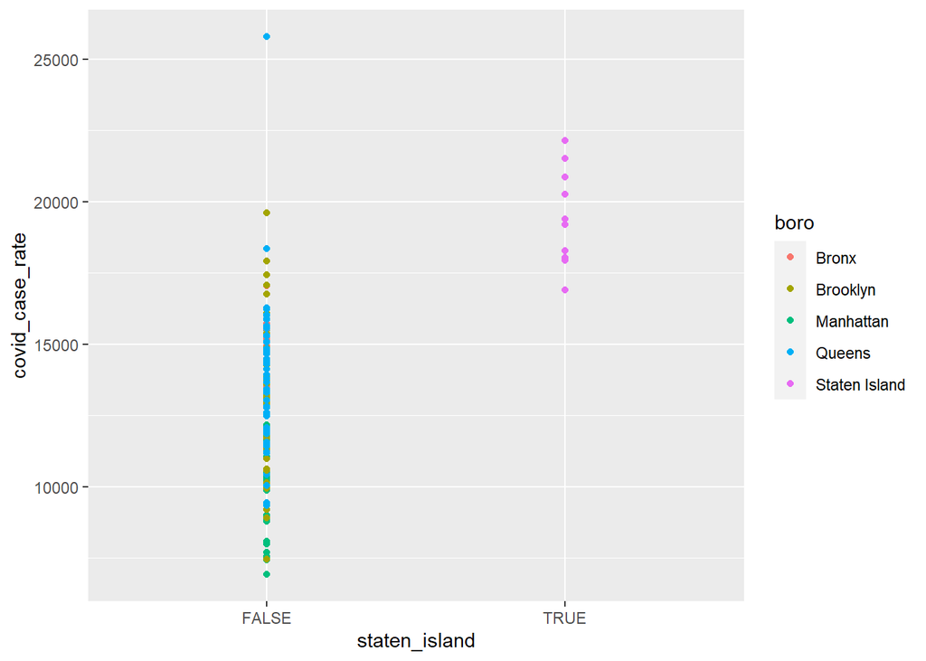

```r
ggplot(data = covidt22) +
  aes(x = staten_island, y = covid_case_rate) +
  geom_point(aes(color = boro)) +
  geom_smooth(method='lm', se = FALSE)
```